# Lab Meeting 10/16

Laurel Diaz

2024-10-16

# Laurel’s Thesis Updates 10/16

#### Material legacies as a result of disturbance events may indirectly alter the physiology of the tropical reef coral, *Porites rus*

## Questions

1. How do simulated shifting community compositions as a result of disturbances change biogeochemistry?
2. How does altered biogeochemistry indirectly impact physiological rates of photosynthesis, respiration, and calcification of *Porites rus*?

## Hypotheses

1. Different dominant benthic communities will alter pH, total alkalinity, dissolved oxygen (DO), and dissolved organic carbon (DOC), with the most significant changes at a peak daytime and peak nighttime.

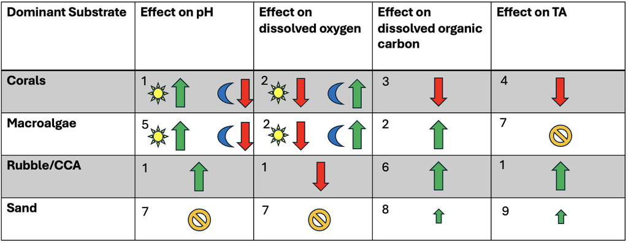

Table 1 - Effect of Dominant Benthic Community on Biogeochemistry

2. Changes in biogeochemistry will impact coral physiology by altering growth and metabolic rates of gross photosynthesis, respiration, and calcification in *Porites rus*.

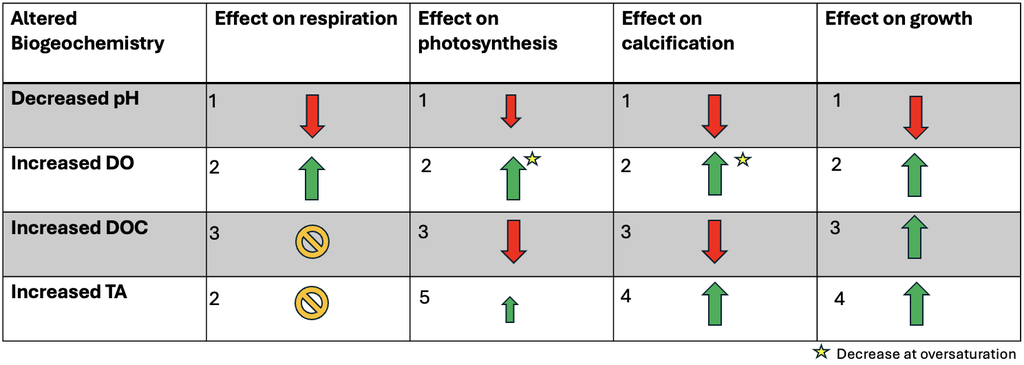

Table 2 - Effect of Changes in Biogeochemistry on Coral Physiology

## Experimental Design

- 4 treatments (n = 4 replicates)
  - “Pre” Disturbances: Coral-Dominated
  - “Post-COTS Outbreak”: Rubble-Dominated
  - “Post-Bleaching Event”: Algae-Dominated
  - Seawater-Only Control
- 2 response tanks per treatment tank (n = 32 total)
  - 3 nubbins of *Porites rus* per response tank
- 25-day experimental period
- Twice daily: pH, salinity, temperature, DO
- Every 5 days (bottle samples): total alkalinity, DOC

## 24-hour Experiment: Determining Peak Day/Night Periods

From June 2nd - June 3rd, we gathered data every: 3 hours for pH (calculated using mV), temperature, salinity, and DO. Every 6 hours, we measured the aforementioned variables in addition to: flow rate (to calculate residence time, delta TA, and NEC), TA, and took samples for DOC.

### Load Libraries

```r
library(tidyverse)
library(seacarb)
library(broom)
library(here)
library(lubridate)
library(ggridges)
library(ggplot2)
library(moments)
library(emmeans)
library(agricolae)
library(tidyr)
library(lmerTest)
```

### Load 24-hr Data

```r
pHcalib<-read_csv(here("Data","Chemistry", "TrisCalSummer2024.csv"))
pHData<-read_csv(here("Data", "Chemistry", "24_hr_carb_chem.csv"))
TableID<-read_csv(here("Data", "TableID.csv"))
```

#### pH

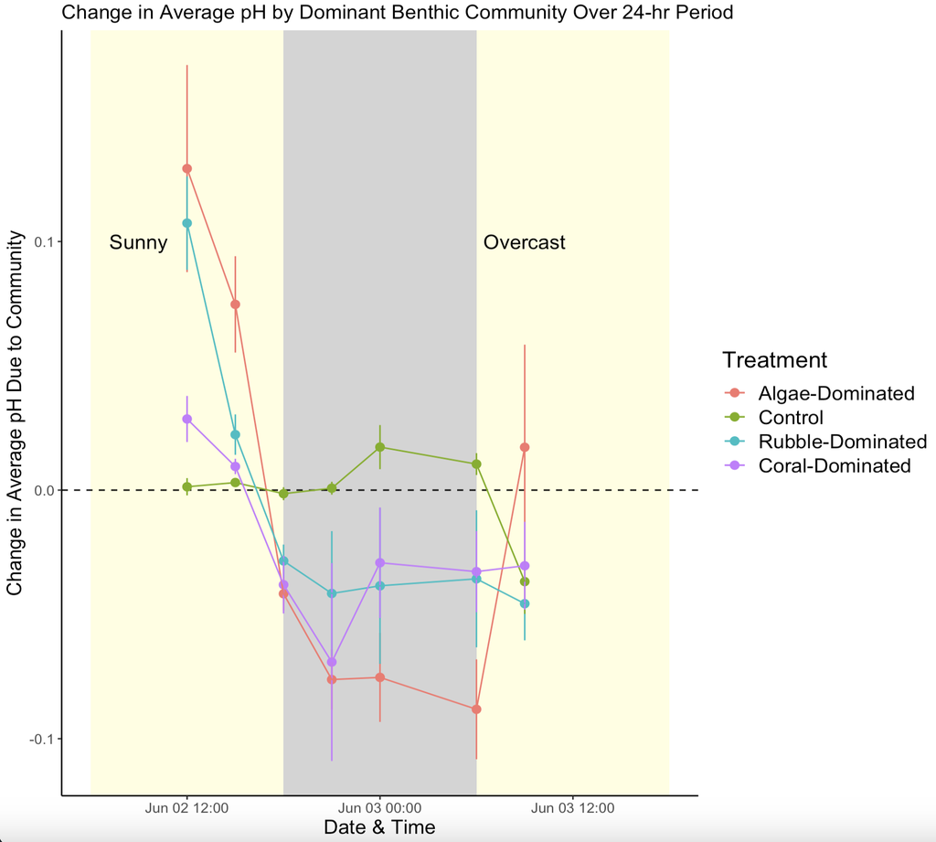

Figure 1 - 24-hr Avg pH plot

```r
pH_community <- lm(pH ~ DateTime*Treatment, data=Data)
#plot(pH_community)
anova(pH_community)
```

```
## Analysis of Variance Table
##
## Response: pH
##                     Df   Sum Sq  Mean Sq F value    Pr(>F)
## DateTime             1 0.176066 0.176066 69.6796 3.188e-13 ***
## Treatment            3 0.006141 0.002047  0.8101   0.49108
## DateTime:Treatment   3 0.028337 0.009446  3.7382   0.01346 *
## Residuals          104 0.262787 0.002527
## ---
## Signif. codes:  0 '***' 0.001 '**' 0.01 '*' 0.05 '.' 0.1 ' ' 1
```

```r
HSD.test(pH_community, "DateTime", console=TRUE)
```

```
##
## Study: pH_community ~ "DateTime"
##
## HSD Test for pH
##
## Mean Square Error:  0.002526795
##
## DateTime,  means
##
##                           pH        std  r         se      Min      Max
## 2024-06-02 12:00:00 8.104310 0.06948252 16 0.01256681 8.030936 8.272669
## 2024-06-02 15:00:00 8.079263 0.03489086 16 0.01256681 8.051109 8.164130
## 2024-06-02 18:00:00 8.028189 0.02189967 16 0.01256681 7.993302 8.059111
## 2024-06-02 21:00:00 7.998571 0.05102255 16 0.01256681 7.869729 8.049390
## 2024-06-03          7.985121 0.04454263 16 0.01256681 7.890482 8.032067
## 2024-06-03 06:00:00 7.977736 0.04853631 16 0.01256681 7.873081 8.029579
## 2024-06-03 09:00:00 7.992490 0.04783286 16 0.01256681 7.935634 8.144885
##                          Q25      Q50      Q75
## 2024-06-02 12:00:00 8.048515 8.085669 8.147666
## 2024-06-02 15:00:00 8.057713 8.064952 8.088008
## 2024-06-02 18:00:00 8.010948 8.029205 8.048537
## 2024-06-02 21:00:00 7.966791 8.016207 8.040408
## 2024-06-03          7.963515 8.000590 8.017032
## 2024-06-03 06:00:00 7.947406 7.991151 8.013914
## 2024-06-03 09:00:00 7.967362 7.974832 8.000049
##
## Alpha: 0.05 ; DF Error: 104
## Critical Value of Studentized Range: 4.252319
##
## Minimun Significant Difference: 0.05343809
##
## Treatments with the same letter are not significantly different.
##
##                           pH groups
## 2024-06-02 12:00:00 8.104310      a
## 2024-06-02 15:00:00 8.079263     ab
## 2024-06-02 18:00:00 8.028189     bc
## 2024-06-02 21:00:00 7.998571      c
## 2024-06-03 09:00:00 7.992490      c
## 2024-06-03          7.985121      c
## 2024-06-03 06:00:00 7.977736      c
```

#### NEC

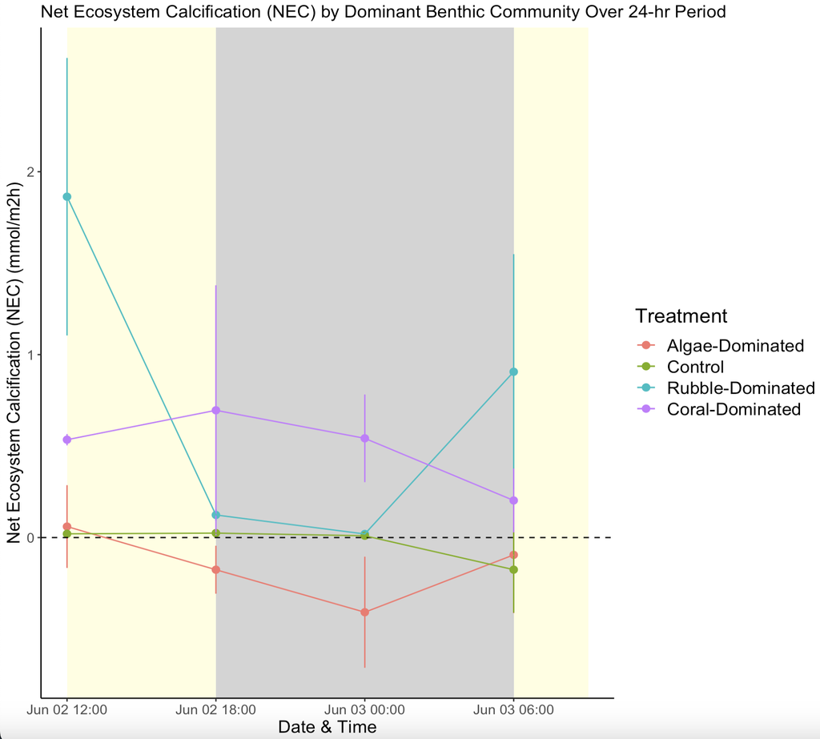

Figure 2 - 24-hr NEC plot

```r
NEC_community <- lm(NEC ~ DateTime*Treatment, data=Data)
#plot(NEC_community)
anova(NEC_community)
```

```
## Analysis of Variance Table
##
## Response: NEC
##                    Df  Sum Sq Mean Sq F value   Pr(>F)
## DateTime            1  2.2501 2.25014  4.7486 0.033623 *
## Treatment           3  8.3759 2.79198  5.8921 0.001461 **
## DateTime:Treatment  3  1.4844 0.49481  1.0442 0.380343
## Residuals          55 26.0619 0.47385
## ---
## Signif. codes:  0 '***' 0.001 '**' 0.01 '*' 0.05 '.' 0.1 ' ' 1
```

```r
HSD.test(NEC_community, "Treatment", console=TRUE)
```

```
##
## Study: NEC_community ~ "Treatment"
##
## HSD Test for NEC
##
## Mean Square Error:  0.4738527
##
## Treatment,  means
##
##                NEC       std  r        se        Min       Max         Q25
## Bleach  -0.2953130 0.4485534 16 0.1720924 -1.3949856 0.4073359 -0.63158247
## Control -0.2032092 0.5024721 16 0.1720924 -1.9241589 0.2311325 -0.23095005
## COTS     0.6108536 1.1774496 16 0.1720924 -0.3227265 3.7633233 -0.08591851
## Pre      0.2340235 0.3937681 15 0.1777363 -0.3361131 0.9682657 -0.02927400
##                 Q50         Q75
## Bleach  -0.15791050 0.007109795
## Control -0.03922458 0.027810573
## COTS     0.07793654 0.909783531
## Pre      0.09477955 0.521279527
##
## Alpha: 0.05 ; DF Error: 55
## Critical Value of Studentized Range: 3.746752
##
## Groups according to probability of means differences and alpha level( 0.05 )
##
## Treatments with the same letter are not significantly different.
##
##                NEC groups
## COTS     0.6108536      a
## Pre      0.2340235     ab
## Control -0.2032092      b
## Bleach  -0.2953130      b
```

## Chlorophyll Content

Chl density (chl a + chl c2 per unit SA) can tell us how “well” the corals are doing in each of the treatments, and can act as a proxy for symbiont and holobiont health. Joyce and Phinn 2003 showed that macroalgae had much greater mean chlorophyll a content compared to *Montipora* spp, *Porites* spp, and sediment + microalgae by more than double.

### Load Chl Plates

```r
PlateData1<-read_csv(here("Data","Data_Raw", "Chl_Content", "Chl_Files", "MO24BEAST_Chl_Run1_Plate1.csv"), skip = 39) #skips first 39 lines
PlateData2<-read_csv(here("Data","Data_Raw", "Chl_Content", "Chl_Files", "MO24BEAST_Chl_Run1_Plate2.csv"), skip = 39)
PlateData2 <- PlateData2[-(24:96),] #this removes empty wells (e.g. not blanks or samples)
```

### Load Chl Metadata

```r
MetaData1<-read_csv(here("Data","Data_Raw","Chl_Content", "Chl_Files", "Metadata1.csv"))
MetaData2<-read_csv(here("Data","Data_Raw","Chl_Content", "Chl_Files", "Metadata2.csv"))
MetaData2 <- MetaData2 %>%
  filter(!CORAL_NUM == "EMPTY") # filters out empty wells
```

### Combine Plates and Metadata - Calculate Chlorophyll

Chl a - 11.43 is the extinction coefficient of chla at wavelength 663 - 0.64 is the extinction coefficient of chla at wavelength 630

Chl c2 - 27.09 is the extinction coefficient of chl c2 at wavelength 630 - 3.63 is the extinction coefficient of chl c2 at wavelength 663

When calculating chlorophyll, we subtract from wavelength of 750 because this is a correction for the turbidity of the sample.

```r
full_data <- cbind(metadata_comb,plates_comb)
full_data <- full_data %>%
  # Calculate chl from Jeffrey and Humphrey (1975)
  # units in µg/ml
  mutate(Chla = (11.43*(`663`-`750`) - 0.64*(`630` - `750`))*1/0.6,
         Chlc = (27.09*(`630` - `750`) - 3.63*(`663` - `750`)*1/0.6))
```

### Normalize Data to Blank

```r
Data_norm <- full_data %>%
  group_by(CORAL_NUM)%>%
  ungroup()%>% # ungroup data so I can just look at coral num and chlorophylls
  reframe(CORAL_NUM = CORAL_NUM,
          Chla_norm = Chla - Chla[CORAL_NUM == "BLANK"], # subtract chla value from blank normalize
          Chlc_norm = Chlc - Chlc[CORAL_NUM == "BLANK"],
          Chl_total = Chla_norm + Chlc_norm)
Data_norm2 <- cbind(full_data, Data_norm)
Data_norm2 <- Data_norm2[-c(11)]
```

### Normalize Chlorophyll Content to Surface Area of Corals

```r
sa <- read_csv(here("Data", "Data_Raw", "Growth", "SA", "MO24BEAST_SA.csv"))
sa$CORAL_NUM <- as.character(sa$CORAL_NUM) # for some reason CORAL_NUM was reading in as double so change to character
chl_full <- full_join(Data_norm2, sa) #full join normalized chl data and surface area data
chl_full <- chl_full %>%
  mutate(chla.ug.cm2 = Chla * 1 / SA_cm_2,
         chlc2.ug.cm2 = Chlc * 1 / SA_cm_2) %>% #add in two new columns - chl a normalized to SA and chl b normalized to SA
  drop_na()
```

### Plot for Chl a

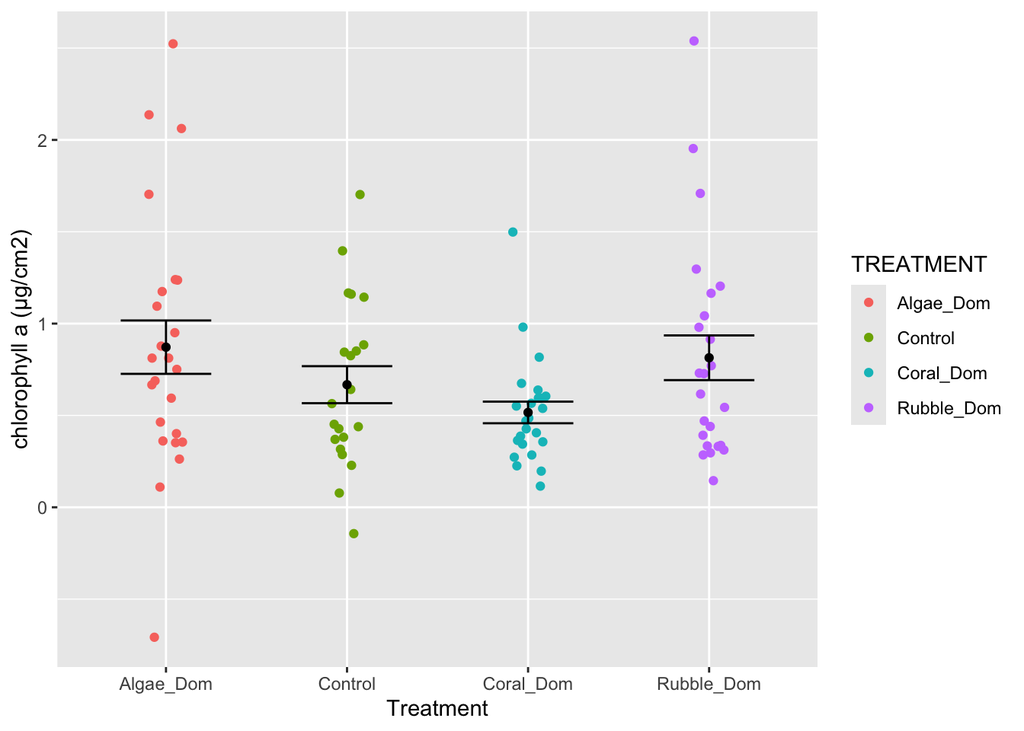

```r
chl_a_plot <- chl_full %>%
  ggplot(aes(x = TREATMENT, y = chla.ug.cm2, color = TREATMENT)) +
  labs(x = "Treatment", y = "chlorophyll a (µg/cm2)") +
  geom_jitter(width = 0.1) +                                            # Plot all points
  stat_summary(fun.data = mean_cl_normal, fun.args = list(mult = 1),    # Plot standard error
               geom = "errorbar", color = "black", width = 0.5) +
  stat_summary(fun.y = mean, geom = "point", color = "black")
chl_a_plot
```

### Stats for Chl a

```r
chla_gen_trtmt_model <- lmer(Chla_norm~TREATMENT + (1|GENOTYPE) +(1|TANKID) + (1|GENOTYPE:TREATMENT) + (1|TANKID:TREATMENT), data=chl_full)
#plot(chla_gen_trtmt_model)
#qqp(residuals(chla_trtmt_model), "norm")
anova(chla_gen_trtmt_model)
```

```
## Type III Analysis of Variance Table with Satterthwaite's method
##               Sum Sq    Mean Sq NumDF DenDF F value Pr(>F)
## TREATMENT 1.1385e-12 3.7951e-13     3     2   1.495 0.4249
```

```r
chla_trtmt_model <- lm(Chla_norm ~ TREATMENT, data=chl_full)
#plot(chla_trtmt_model)
#qqp(residuals(chla_trtmt_model), "norm")
anova(chla_trtmt_model)
```

```
## Analysis of Variance Table
##
## Response: Chla_norm
##           Df  Sum Sq Mean Sq F value Pr(>F)
## TREATMENT  3   9.267  3.0889  1.6751 0.1781
## Residuals 89 164.123  1.8441
```

```r
anova(chla_gen_trtmt_model, chla_trtmt_model)
```

```
## Data: chl_full
## Models:
## chla_trtmt_model: Chla_norm ~ TREATMENT
## chla_gen_trtmt_model: Chla_norm ~ TREATMENT + (1 | GENOTYPE) + (1 | TANKID) + (1 | GENOTYPE:TREATMENT) + (1 | TANKID:TREATMENT)
##                      npar    AIC    BIC  logLik deviance Chisq Df Pr(>Chisq)
## chla_trtmt_model        5 326.75 339.41 -158.37   316.75
## chla_gen_trtmt_model    9 305.40 328.19 -143.70   287.40 29.35  4  6.637e-06
##
## chla_trtmt_model
## chla_gen_trtmt_model ***
## ---
## Signif. codes:  0 '***' 0.001 '**' 0.01 '*' 0.05 '.' 0.1 ' ' 1
```

### Plot for Chl c

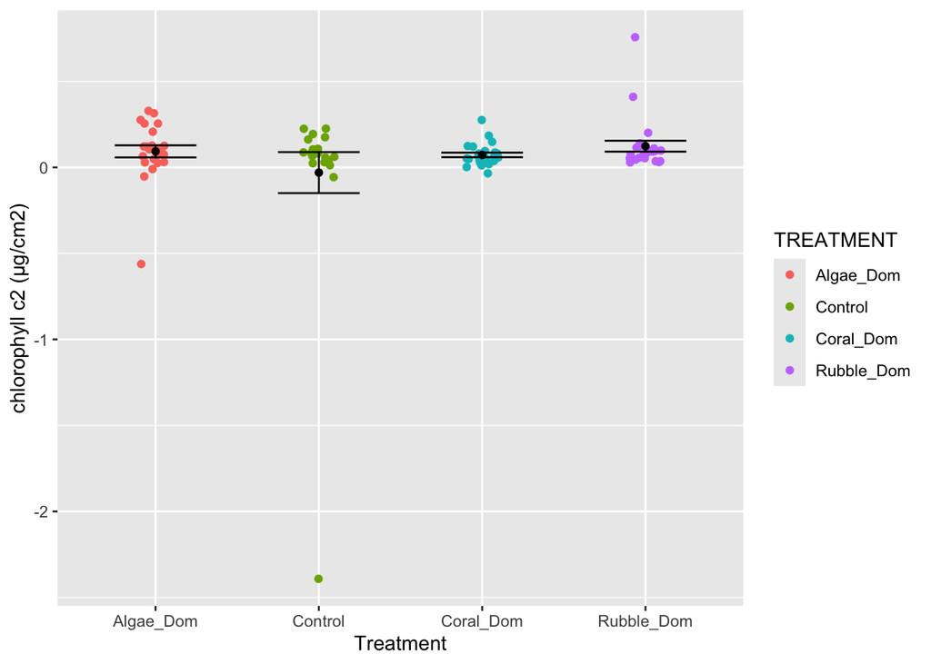

```r
chl_c_plot <- chl_full %>%
  ggplot(aes(x = TREATMENT, y = chlc2.ug.cm2, color = TREATMENT)) +
  labs(x = "Treatment", y = "chlorophyll c2 (µg/cm2)") +
  geom_jitter(width = 0.1) +
  stat_summary(fun.data = mean_cl_normal, fun.args = list(mult = 1),
               geom = "errorbar", color = "black", width = 0.5) +
  stat_summary(fun.y = mean, geom = "point", color = "black")
chl_c_plot
```

### Chl C Stats

```r
chlc_gen_trtmt_model <- lmer(Chlc_norm~TREATMENT + (1|GENOTYPE) + (1|TANKID) + (1|GENOTYPE:TREATMENT) + (1|TANKID:TREATMENT), data=chl_full)
#plot(chlc_gen_trtmt_model) #yikes
#qqp(residuals(chlc_gen_trtmt_model), "norm")
anova(chlc_gen_trtmt_model)
```

```
## Type III Analysis of Variance Table with Satterthwaite's method
##               Sum Sq    Mean Sq NumDF DenDF F value Pr(>F)
## TREATMENT 1.6041e-14 5.3469e-15     3     2  0.7977  0.598
```

```r
chlc_trtmt_model <- lm(Chlc_norm ~ TREATMENT, data=chl_full)
#qqp(residuals(chlc_trtmt_model), "norm")
anova(chlc_trtmt_model)
```

```
## Analysis of Variance Table
##
## Response: Chlc_norm
##           Df Sum Sq Mean Sq F value Pr(>F)
## TREATMENT  3  1.002 0.33402  0.8295 0.4811
## Residuals 89 35.840 0.40270
```

The outliers seen in both Chl a and Chl c2 are most likely caused by an incorrect reading from the spec - these will be rerun here at CSUN, stay tuned! :)

### Change in Chl a

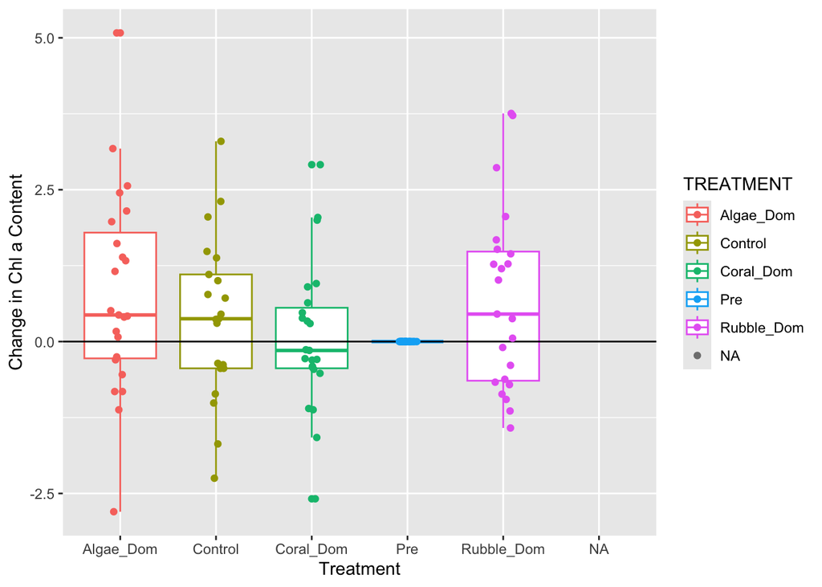

```r
chl_initial <- Data_norm2 %>%
  filter(TREATMENT == "Pre") %>%
  select(TREATMENT, CORAL_NUM, GENOTYPE, Chla_norm, Chlc_norm)

full_data2 <- Data_norm2 %>%
  left_join(chl_initial, by = "GENOTYPE") %>%
  rename(Chla_norm_initial = Chla_norm.y,
         Chlc_norm_initial = Chlc_norm.y,
         CORAL_NUM = CORAL_NUM.x,
         TREATMENT = TREATMENT.x,
         Chla_norm = Chla_norm.x,
         Chlc_norm = Chlc_norm.x,
         )
full_data2 <- full_data2[-c(14:15)]

full_data2 <- full_data2 %>%
  mutate(Chla_diff = (Chla_norm - Chla_norm_initial),
         Chlc_diff = (Chlc_norm - Chlc_norm_initial))

chla_change_plot <- full_data2 %>%
  ggplot(aes(x = TREATMENT, y = Chla_diff, color = TREATMENT)) +
  geom_boxplot() +
  geom_hline(yintercept = 0) +
  labs(x = "Treatment", y = "Change in Chl a Content") +
  geom_jitter(width = 0.1)
chla_change_plot
```